# Cherry Blossom Trees — Individual Tree Map

```r
library(sf)
library(dplyr)
library(ggplot2)
library(tidyr)
library(DT)
library(mapgl)
library(here)
```

```r
neighbourhoods <- st_read(
  here("data/original/local-area-boundary.geojson"),
  quiet = TRUE
)
cherry_trees <- st_read(
  here("data/final/cherry_blossoms.geojson"),
  quiet = TRUE
)

cherry_trees <- st_transform(cherry_trees, st_crs(neighbourhoods))
```

```r
# Spatial join to attach neighbourhood name to each tree
cherry_trees <- st_join(
  cherry_trees,
  neighbourhoods %>% select(neighbourhood = name),
  join = st_within
)
```

```r
# 10 cherry blossom species — pinks, whites, and warm tones
species_levels <- sort(unique(cherry_trees$common_name))

species_colours <- c(
  "AKEBONO FLOWERING CHERRY" = "#f4a7b9",
  "AMANOGAWA JAPANESE CHERRY" = "#e8739a",
  "DOUBLE WEEPING JAPANESE CHERRY" = "#c94080",
  "JAPANESE FLOWERING CHERRY" = "#f9c8d8",
  "KWANZAN FLOWERING CHERRY" = "#e84393",
  "OJOCHIN JAPANESE CHERRY" = "#d4548a",
  "SARGENT FLOWERING CHERRY" = "#b03060",
  "SHOGETSU JAPANESE CHERRY" = "#fde8f0",
  "UKON JAPANESE CHERRY" = "#c8b400",
  "WEEPING JAPANESE CHERRY" = "#9b2257"
)

# Build match_expr pairs: species name -> colour
colour_pairs <- unlist(
  lapply(names(species_colours), function(s) {
    list(s, unname(species_colours[s]))
  }),
  recursive = FALSE
)
```

## All trees

```r
maplibre(
  style = openfreemap_style("bright"),
  bounds = neighbourhoods
) %>%
  # Neighbourhood polygon base
  add_fill_layer(
    id = "neighbourhoods",
    source = neighbourhoods,
    fill_color = "#f5e6ef",
    fill_opacity = 0.35
  ) %>%
  add_line_layer(
    id = "neighbourhood-borders",
    source = neighbourhoods,
    line_color = "#c47fa0",
    line_width = 1,
    line_opacity = 0.7
  ) %>%
  # Individual trees coloured by species
  add_circle_layer(
    id = "cherry-trees",
    source = cherry_trees,
    circle_color = match_expr(
      column = "common_name",
      values = names(species_colours),
      stops = unname(species_colours),
      default = "#aaaaaa"
    ),
    circle_radius = 4,
    circle_opacity = 0.8,
    circle_stroke_color = "white",
    circle_stroke_width = 0.5,
    tooltip = concat(
      "<b>",
      get_column("common_name"),
      "</b><br/>",
      "<i>Prunus ",
      get_column("species_name"),
      " '",
      get_column("cultivar_name"),
      "'</i><br/><br/>",
      "Neighbourhood: ",
      get_column("neighbourhood"),
      "<br/>",
      "Age: ",
      get_column("age_years"),
      " yrs<br/>",
      "Height: ",
      get_column("height_m"),
      " m<br/>",
      "Diameter: ",
      get_column("diameter_cm"),
      " cm"
    )
  ) %>%
  add_categorical_legend(
    legend_title = "Species",
    values = names(species_colours),
    colors = unname(species_colours),
    position = "bottom-right"
  )
```

[interactive chart not shown]

## Trees under 2.5 m

10 trees with a recorded height below 2.5 m.

```r
maplibre(style = openfreemap_style("bright"), bounds = neighbourhoods) %>%
  add_fill_layer(
    id = "neighbourhoods",
    source = neighbourhoods,
    fill_color = "#f5e6ef",
    fill_opacity = 0.35
  ) %>%
  add_line_layer(
    id = "neighbourhood-borders",
    source = neighbourhoods,
    line_color = "#c47fa0",
    line_width = 1,
    line_opacity = 0.7
  ) %>%
  add_circle_layer(
    id = "cherry-trees-short",
    source = trees_short,
    circle_color = match_expr(
      column = "common_name",
      values = names(species_colours),
      stops = unname(species_colours),
      default = "#aaaaaa"
    ),
    circle_radius = 4,
    circle_opacity = 0.8,
    circle_stroke_color = "white",
    circle_stroke_width = 0.5,
    tooltip = concat(
      "<b>",
      get_column("common_name"),
      "</b><br/>",
      "<i>Prunus ",
      get_column("species_name"),
      " '",
      get_column("cultivar_name"),
      "'</i><br/><br/>",
      "Neighbourhood: ",
      get_column("neighbourhood"),
      "<br/>",
      "Age: ",
      get_column("age_years"),
      " yrs<br/>",
      "Height: ",
      get_column("height_m"),
      " m<br/>",
      "Diameter: ",
      get_column("diameter_cm"),
      " cm"
    )
  ) %>%
  add_categorical_legend(
    legend_title = "Species",
    values = names(species_colours),
    colors = unname(species_colours),
    position = "bottom-right"
  )
```

[interactive chart not shown]

## Trees 2.5 m and taller

14983 trees with a recorded height of 2.5 m or more.

```r
maplibre(style = openfreemap_style("bright"), bounds = neighbourhoods) %>%
  add_fill_layer(
    id = "neighbourhoods",
    source = neighbourhoods,
    fill_color = "#f5e6ef",
    fill_opacity = 0.35
  ) %>%
  add_line_layer(
    id = "neighbourhood-borders",
    source = neighbourhoods,
    line_color = "#c47fa0",
    line_width = 1,
    line_opacity = 0.7
  ) %>%
  add_circle_layer(
    id = "cherry-trees-tall",
    source = trees_tall,
    circle_color = match_expr(
      column = "common_name",
      values = names(species_colours),
      stops = unname(species_colours),
      default = "#aaaaaa"
    ),
    circle_radius = 4,
    circle_opacity = 0.8,
    circle_stroke_color = "white",
    circle_stroke_width = 0.5,
    tooltip = concat(
      "<b>",
      get_column("common_name"),
      "</b><br/>",
      "<i>Prunus ",
      get_column("species_name"),
      " '",
      get_column("cultivar_name"),
      "'</i><br/><br/>",
      "Neighbourhood: ",
      get_column("neighbourhood"),
      "<br/>",
      "Age: ",
      get_column("age_years"),
      " yrs<br/>",
      "Height: ",
      get_column("height_m"),
      " m<br/>",
      "Diameter: ",
      get_column("diameter_cm"),
      " cm"
    )
  ) %>%
  add_categorical_legend(
    legend_title = "Species",
    values = names(species_colours),
    colors = unname(species_colours),
    position = "bottom-right"
  )
```

[interactive chart not shown]

## Data completeness

How many trees have recorded values for the three columns that drive the bloom-readiness filter — `date_planted` (→ age), `height_m`, and `diameter_cm`?

`date_planted` is missing for **10879** trees (**72.6%** of the dataset), meaning age cannot be computed for them and they will always be excluded by the age filter regardless of thresholds.

```r
total <- nrow(cherry_trees)

overall <- cherry_trees %>%
  st_drop_geometry() %>%
  summarise(
    across(
      c(date_planted, height_m, diameter_cm),
      list(
        n_missing = \(x) sum(is.na(x)),
        pct_missing = \(x) round(mean(is.na(x)) * 100, 1),
        n_recorded = \(x) sum(!is.na(x)),
        pct_recorded = \(x) round(mean(!is.na(x)) * 100, 1)
      )
    )
  ) %>%
  pivot_longer(
    everything(),
    names_to = c("column", ".value"),
    names_pattern = "(.+)_(n_missing|pct_missing|n_recorded|pct_recorded)"
  ) %>%
  mutate(
    column = recode(
      column,
      date_planted = "date_planted → age_years",
      height_m = "height_m",
      diameter_cm = "diameter_cm"
    ),
    total = total
  ) %>%
  select(
    Column = column,
    Total = total,
    Recorded = n_recorded,
    `% Recorded` = pct_recorded,
    Missing = n_missing,
    `% Missing` = pct_missing
  )

datatable(
  overall,
  caption = paste("Overall data completeness (n =", total, "trees)"),
  rownames = FALSE,
  options = list(dom = "t", pageLength = 3)
) %>%
  formatStyle(
    "% Missing",
    backgroundColor = styleInterval(
      c(10, 50),
      c("#d4edda", "#fff3cd", "#f8d7da")
    )
  )
```

| Column | Total | Recorded | % Recorded | Missing | % Missing |
| --- | --- | --- | --- | --- | --- |
| date_planted → age_years | 14993 | 4114 | 27.4 | 10879 | 72.6 |
| height_m | 14993 | 14993 | 100 | 0 | 0 |
| diameter_cm | 14993 | 14993 | 100 | 0 | 0 |

```r
by_species <- cherry_trees %>%
  st_drop_geometry() %>%
  group_by(Species = common_name) %>%
  summarise(
    Total = n(),
    Age = sum(!is.na(date_planted)),
    Height = sum(!is.na(height_m)),
    Diameter = sum(!is.na(diameter_cm)),
    All_three = sum(
      !is.na(date_planted) & !is.na(height_m) & !is.na(diameter_cm)
    ),
    .groups = "drop"
  ) %>%
  mutate(
    `Age %` = round(Age / Total * 100, 1),
    `Height %` = round(Height / Total * 100, 1),
    `Diameter %` = round(Diameter / Total * 100, 1),
    `All three %` = round(All_three / Total * 100, 1)
  ) %>%
  arrange(desc(Total))

datatable(
  by_species %>%
    select(
      Species,
      Total,
      Age,
      `Age %`,
      Height,
      `Height %`,
      Diameter,
      `Diameter %`,
      `All three %`
    ),
  caption = "Recorded values per column, by species",
  rownames = FALSE,
  options = list(dom = "t", pageLength = 15)
) %>%
  formatStyle(
    c("Age %", "Height %", "Diameter %", "All three %"),
    backgroundColor = styleInterval(
      c(50, 90),
      c("#f8d7da", "#fff3cd", "#d4edda")
    )
  )
```

| Species | Total | Age | Age % | Height | Height % | Diameter | Diameter % | All three % |
| --- | --- | --- | --- | --- | --- | --- | --- | --- |
| KWANZAN FLOWERING CHERRY | 9903 | 1935 | 19.5 | 9903 | 100 | 9903 | 100 | 19.5 |
| AKEBONO FLOWERING CHERRY | 2464 | 2110 | 85.6 | 2464 | 100 | 2464 | 100 | 85.6 |
| JAPANESE FLOWERING CHERRY | 1579 | 41 | 2.6 | 1579 | 100 | 1579 | 100 | 2.6 |
| UKON JAPANESE CHERRY | 711 | 3 | 0.4 | 711 | 100 | 711 | 100 | 0.4 |
| SARGENT FLOWERING CHERRY | 161 | 2 | 1.2 | 161 | 100 | 161 | 100 | 1.2 |
| WEEPING JAPANESE CHERRY | 78 | 0 | 0 | 78 | 100 | 78 | 100 | 0 |
|  | 48 | 18 | 37.5 | 48 | 100 | 48 | 100 | 37.5 |
| AMANOGAWA JAPANESE CHERRY | 44 | 5 | 11.4 | 44 | 100 | 44 | 100 | 11.4 |
| OJOCHIN JAPANESE CHERRY | 3 | 0 | 0 | 3 | 100 | 3 | 100 | 0 |
| DOUBLE WEEPING JAPANESE CHERRY | 1 | 0 | 0 | 1 | 100 | 1 | 100 | 0 |

[output cut: 1 more lines]

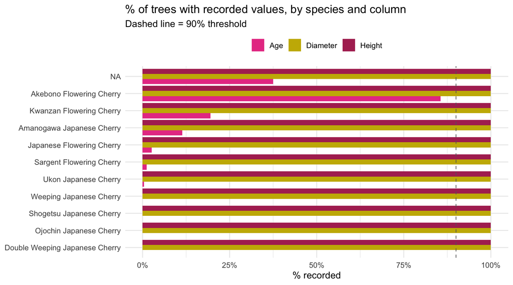

```r
by_species %>%
  select(
    Species,
    Age = `Age %`,
    Height = `Height %`,
    Diameter = `Diameter %`
  ) %>%
  pivot_longer(-Species, names_to = "Column", values_to = "pct_recorded") %>%
  mutate(Species = stringr::str_to_title(Species)) %>%
  ggplot(aes(
    x = reorder(Species, pct_recorded),
    y = pct_recorded,
    fill = Column
  )) +
  geom_col(position = "dodge") +
  geom_hline(
    yintercept = 90,
    linetype = "dashed",
    colour = "grey40",
    linewidth = 0.4
  ) +
  coord_flip() +
  scale_fill_manual(
    values = c(Age = "#e84393", Height = "#b03060", Diameter = "#c8b400")
  ) +
  scale_y_continuous(limits = c(0, 100), labels = \(x) paste0(x, "%")) +
  labs(
    title = "% of trees with recorded values, by species and column",
    subtitle = "Dashed line = 90% threshold",
    x = NULL,
    y = "% recorded",
    fill = NULL
  ) +
  theme_minimal(base_size = 12) +
  theme(legend.position = "top")
```

## Conclusion

- Can’t use the date to calculate age for filtering trees. There’s too much missing data to make it useful.
  - When I first ran the analysis filtering on trees older than 5 years old, the results made no sense
    - No areas from the original top 30 analysis
    - David Lam Park had no trees (this is where the cherry blossom festival is held!)
- Tree dimension data is recorded and has 100% complete data.
  - However this will assume the height is up to date.
- I can count the number of trees under 2.5m in the dataset, so using these dimensions won’t really affect the final analysis.